# Beta-Diversity

Karina Zhang

2026-04-15

# Inputs:

- preprocessed_physeq: asv, count table, metadata, taxonomy

# Outputs

- visualize data in ordinations (PCoA or NMDs) -Calculate stats (PERMANOVA and betadisper)

```r
pacman::p_load(tidyverse, phyloseq, patchwork, vegan,
               install = FALSE)

# Load colors and shapes
source("/local/workdir/yz3272/Biodiversity_Salinity_16S/code/colors_and_shapes.R")
source("/local/workdir/yz3272/Biodiversity_Salinity_16S/code/functions.R")

#load data
load("/local/workdir/yz3272/BIOMI6300_IronMicrobiotaProject/03_Pre-processing/preprocessed_phyloseq.RData")
preprocessed_physeq
```

```
## phyloseq-class experiment-level object
## otu_table()   OTU Table:         [ 1591 taxa and 102 samples ]
## sample_data() Sample Data:       [ 102 samples by 3 sample variables ]
## tax_table()   Taxonomy Table:    [ 1591 taxa by 9 taxonomic ranks ]
```

```r
# Intuition check on seq depth
min(sample_sums(preprocessed_physeq))
```

```
## [1] 21454
```

###INTERPRETATION 1: My scientific question is whether feeding mice a low-iron diet versus a high-iron diet is associated with differences in the gut microbial community profile. My hypothesis is that greater dietary iron intake results in more unabsorbed iron reaching the murine colon, which may selectively promote or suppress the growth of specific microbial taxa. Consequently, the microbial community structure is expected to differ between diet groups. Because this hypothesis concerns changes in the abundance of taxa rather than simply their presence or absence, this analysis primarily relates to abundance-weighted metrics (relative abundance).

```r
metadata_df <- sample_data(preprocessed_physeq) %>%
  data.frame() %>%
  filter(Group == "HC", Iron.intake %in% c("50", "500"))

physeq_HC <- prune_samples(rownames(metadata_df), preprocessed_physeq)
physeq_HC <- prune_taxa(taxa_sums(physeq_HC) > 0, physeq_HC)
```

```r
# Drop taxa with zero counts after subsetting
physeq_HC <- prune_taxa(taxa_sums(physeq_HC) > 0, physeq_HC)

# calculate read counts per sample
raw_TotalSeqs_df <-
  physeq_HC %>%
  sample_sums() %>%
  data.frame()

# Rename the column
colnames(raw_TotalSeqs_df)[1] <- "TotalSeqs"

# Add sample IDs as a column
raw_TotalSeqs_df$SampleID <- rownames(raw_TotalSeqs_df)

# Calculate number of observed ASVs per sample
otu_mat <- as(otu_table(physeq_HC), "matrix")

# Make sure samples are rows
if (taxa_are_rows(physeq_HC)) {
  otu_mat <- t(otu_mat)
}

num_ASVs_per_sample <- rowSums(otu_mat > 1)

# add a new column of num_ASVs (RAW, non-normalized # ASVs per sample)
raw_TotalSeqsASVs_df <-
  raw_TotalSeqs_df %>%
  mutate(num_ASVs = num_ASVs_per_sample)

# Plot histogram of seq depth
rawSeq_histogram <-
  raw_TotalSeqsASVs_df %>%
  ggplot(aes(x = TotalSeqs)) +
  geom_histogram(bins = 30) +
  scale_x_continuous(limits = c(0, 70000)) +
  labs(title = "Raw Seq Depth Histogram: HC50 and HC500") +
  theme_bw()

# Plot Seq Depth versus num_ASVs
rawSeq_vs_numASV_plot <-
  raw_TotalSeqsASVs_df %>%
  ggplot(aes(x = num_ASVs, y = TotalSeqs)) +
  geom_point() +
  scale_y_continuous(limits = c(0, 70000)) +
  geom_smooth(method = "lm") +
  labs(title = "Seq Depth vs # ASVs: HC50 and HC500") +
  theme_bw()

# is it significant?
summary(lm(TotalSeqs ~ num_ASVs, data = raw_TotalSeqsASVs_df))
```

```
##
## Call:
## lm(formula = TotalSeqs ~ num_ASVs, data = raw_TotalSeqsASVs_df)
##
## Residuals:
##    Min     1Q Median     3Q    Max
## -12733  -5710  -1161   4894  22505
##
## Coefficients:
##             Estimate Std. Error t value Pr(>|t|)
## (Intercept) 37075.92    4325.78   8.571 3.06e-11 ***
## num_ASVs      -27.51      38.22  -0.720    0.475
## ---
## Signif. codes:  0 '***' 0.001 '**' 0.01 '*' 0.05 '.' 0.1 ' ' 1
##
## Residual standard error: 7644 on 48 degrees of freedom
## Multiple R-squared:  0.01068,    Adjusted R-squared:  -0.009933
## F-statistic: 0.5181 on 1 and 48 DF,  p-value: 0.4752
```

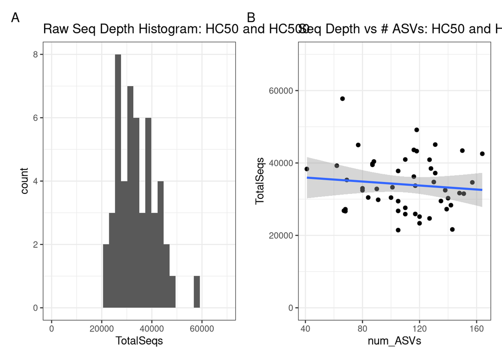

```r
# Put the two plots together
rawSeq_histogram + rawSeq_vs_numASV_plot +
  plot_annotation(tag_levels = "A")
```

###INTERPRETATION 2: The raw sequencing depths for HC_50 and HC_500 samples ranged from 21,000 to 58,000 reads, so read counts were scaled to the minimum sample depth to retain all samples while standardizing library size across groups. This scaling helps to reduce bias from unequal sequencing depth in downstream beta-diversity analyses, however, this way it discards a great portion of reads from deeper samples. Consequently, it may decrease the sensitivity to minor community differences and rare taxa abundance.

```r
min(sample_sums(preprocessed_physeq))
```

```
## [1] 21454
```

```r
# Scale the reads
scaled_physeq <-
  physeq_HC %>%
  scale_reads(round = "matround")

# Look at it
scaled_physeq
```

```
## phyloseq-class experiment-level object
## otu_table()   OTU Table:         [ 964 taxa and 50 samples ]
## sample_data() Sample Data:       [ 50 samples by 3 sample variables ]
## tax_table()   Taxonomy Table:    [ 964 taxa by 9 taxonomic ranks ]
```

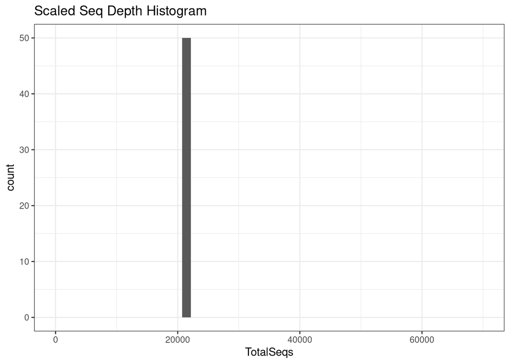

```r
# Look at it more!
#View(data.frame(otu_table(preprocessed_physeq)))
#View(data.frame(otu_table(scaled_physeq)))

# Confirm seq read depth of scaled_physeq
scaled_TotalSeqs_df <-
  scaled_physeq %>%
  sample_sums() %>%
  data.frame()

colnames(scaled_TotalSeqs_df)[1] <- "TotalSeqs"

# add a new column of num_ASVs (RAW, non-noramlized # ASVs)
scaled_TotalSeqsASVs_df <-
  scaled_TotalSeqs_df %>%
  mutate(num_ASVs = colSums(otu_table(scaled_physeq) > 1))

# Plot it!
scaledSeq_histogram <-
  scaled_TotalSeqs_df %>%
  ggplot(aes(x = TotalSeqs)) +
  geom_histogram(bins = 50) +
  labs(title = "Scaled Seq Depth Histogram") +
  scale_x_continuous(limits = c(0, 70000)) +
  theme_bw()
scaledSeq_histogram
```

```r
# Scaling always gives us a range!
# MInimum sequences
min(scaled_TotalSeqs_df$TotalSeqs)
```

```
## [1] 21440
```

```r
# Total Range
range(scaled_TotalSeqs_df) # a range happen due to the scaling factor differ for each sample
```

```
## [1] 21440 21474
```

```r
# How many is that range?
range_seqs <- (max(scaled_TotalSeqs_df$TotalSeqs) - min(scaled_TotalSeqs_df$TotalSeqs))
range_seqs
```

```
## [1] 34
```

```r
range_seqs/max(scaled_TotalSeqs_df$TotalSeqs)
```

```
## [1] 0.00158331
```

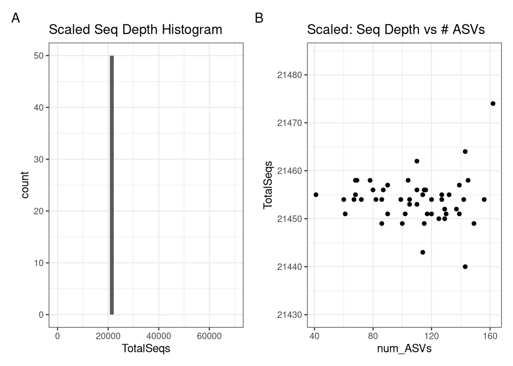

```r
#View(scaled_TotalSeqs_df)

# Set the axis min and max for the next plot
max_y <- max(scaled_TotalSeqs_df$TotalSeqs) + 10
min_y <- min(scaled_TotalSeqs_df$TotalSeqs) - 10

# Now, draw the plot
scaledSeq_vs_numASV_plot <-
  scaled_TotalSeqsASVs_df %>%
  ggplot(aes(x = num_ASVs, y = TotalSeqs)) +
  geom_point() +
  scale_y_continuous(limits = c(min_y, max_y)) +
  #geom_smooth(method = "lm") +
  theme_bw() +
  labs(title = "Scaled: Seq Depth vs # ASVs")

# Put the two plots together.
scaledSeq_histogram + scaledSeq_vs_numASV_plot +
  plot_annotation(tag_levels = "A")
```

###INTERPRETATION 3: After scaling, the total number of sequences across all HC samples was brought into the same general range, between 21,440 and 21,474 reads (a difference of only 34 reads, ~0.16%). The association between number of ASVs and read counts was flatter, therefore, downstream beta diversity analysis will like reflect true community differences instead of sequencing depth related artifacts.

```r
sample_data(scaled_physeq)$Iron.intake <- factor(
  sample_data(scaled_physeq)$Iron.intake,
  levels = c(50, 500),
  labels = c("HC50", "HC500")
)

# Bray-Curtis Dissimiliarty
scaled_bray_dist <- phyloseq::distance(scaled_physeq, method = "bray", binary = FALSE)
str(scaled_bray_dist)
```

```
##  'dist' num [1:1225] 0.27 0.373 0.39 0.508 0.59 ...
##  - attr(*, "maxdist")= num 1
##  - attr(*, "Size")= int 50
##  - attr(*, "Labels")= chr [1:50] "SRR29920109" "SRR29920120" "SRR29920131" "SRR29920142" ...
##  - attr(*, "Diag")= logi FALSE
##  - attr(*, "Upper")= logi FALSE
##  - attr(*, "method")= chr "bray"
##  - attr(*, "call")= language vegdist(x = c(10849, 7362, 11972, 12317, 5169, 6439, 10104, 6058, 15456,  4940, 459, 3075, 1866, 7557, 3546, 2084| __truncated__ ...
```

```r
bray_permanova <- adonis2(
  scaled_bray_dist ~ Iron.intake,
  data = metadata_df
)
bray_permanova
```

```
## Permutation test for adonis under reduced model
## Permutation: free
## Number of permutations: 999
##
## adonis2(formula = scaled_bray_dist ~ Iron.intake, data = metadata_df)
##          Df SumOfSqs      R2      F Pr(>F)
## Model     1   0.3123 0.03517 1.7496  0.091 .
## Residual 48   8.5685 0.96483
## Total    49   8.8808 1.00000
## ---
## Signif. codes:  0 '***' 0.001 '**' 0.01 '*' 0.05 '.' 0.1 ' ' 1
```

```r
### for exploration, run Sorensen to test the persence of major memebers:
# Sorensen Dissimiliarty
scaled_sorensen_dist <- phyloseq::distance(scaled_physeq, method = "bray", binary = TRUE)

sorensen_permanova <- adonis2(
  scaled_sorensen_dist ~ Iron.intake,
  data = metadata_df
)
sorensen_permanova
```

```
## Permutation test for adonis under reduced model
## Permutation: free
## Number of permutations: 999
##
## adonis2(formula = scaled_sorensen_dist ~ Iron.intake, data = metadata_df)
##          Df SumOfSqs      R2      F Pr(>F)
## Model     1   0.2846 0.02839 1.4027  0.096 .
## Residual 48   9.7375 0.97161
## Total    49  10.0220 1.00000
## ---
## Signif. codes:  0 '***' 0.001 '**' 0.01 '*' 0.05 '.' 0.1 ' ' 1
```

```r
# What does it look like?
class(scaled_sorensen_dist)
```

```
## [1] "dist"
```

```r
str(scaled_sorensen_dist)
```

```
##  'dist' num [1:1225] 0.386 0.685 0.655 0.594 0.716 ...
##  - attr(*, "maxdist")= num 1
##  - attr(*, "Size")= int 50
##  - attr(*, "Labels")= chr [1:50] "SRR29920109" "SRR29920120" "SRR29920131" "SRR29920142" ...
##  - attr(*, "Diag")= logi FALSE
##  - attr(*, "Upper")= logi FALSE
##  - attr(*, "method")= chr "binary bray"
##  - attr(*, "call")= language vegdist(x = c(10849, 7362, 11972, 12317, 5169, 6439, 10104, 6058, 15456,  4940, 459, 3075, 1866, 7557, 3546, 2084| __truncated__ ...
```

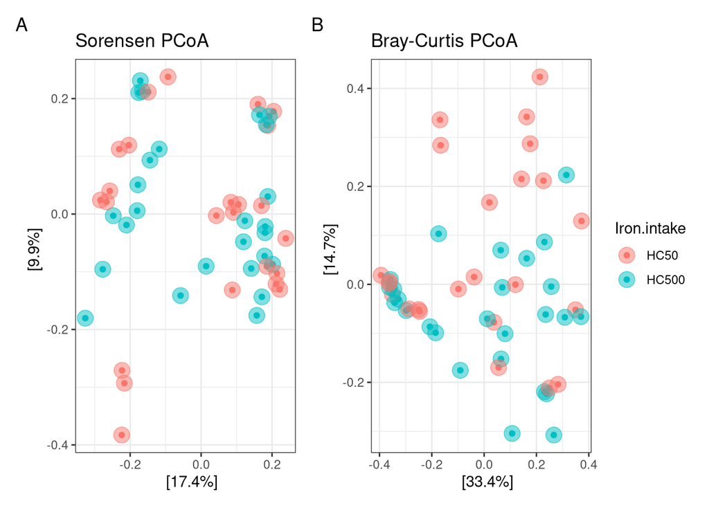

```r
scaled_bray_pcoa <-
  ordinate(physeq = scaled_physeq,
         method = "PCoA",
         distance = "bray", binary = FALSE)

# Plot it: Bray-Curtis PCoA
bray_pcoa_plot <-
  plot_ordination(physeq = scaled_physeq,
                ordination = scaled_bray_pcoa,
                color = "Iron.intake",
                title = "Bray-Curtis PCoA") +
  geom_point(size = 5, alpha = 0.5, aes(color = Iron.intake)) +
  theme_bw() +
  theme(legend.position = "right")
# Calculate PCoA with Sorensen dissimilarity
scaled_sorensen_pcoa <-
  ordinate(
    physeq = scaled_physeq,
    method = "PCoA",
    distance = "bray",
    binary = TRUE
  )

# Plot it: Sorensen PCoA
sorensen_pcoa_plot <-
  plot_ordination(
    physeq = scaled_physeq,
    ordination = scaled_sorensen_pcoa,
    color = "Iron.intake",
    title = "Sorensen PCoA"
  ) +
  geom_point(size = 5, alpha = 0.5, aes(color = Iron.intake)) +
  theme_bw() +
  theme(legend.position = "right")

# Show the plots
sorensen_pcoa_plot+ bray_pcoa_plot +
  plot_layout(guides = "collect") +
  plot_annotation(tag_levels = "A")
```

###INTERPRETATION 5: The Bray–Curtis PCoA shows that the first two axes explain 33.4% and 14.7% of variation in the microbial community composition. HC_50 and HC_500 groups overlap substantially with no clustering observed, suggesting different iron dose (10-fold diff in non-heme content) has little effect on the gut microbiome diversity; this is also confirmed with PERMANOVA having a p-value of 0.1. The Sorensen plot did not capture as much diff as bray crutis PCoA plot, but basically telling the same story that the beta diverstiy did not diff sig. between groups.

```r
# Up till here, i don't think NMD plot is necessary given my PCoA explains~48% of the distribution diff. just plotting to learn the code
scaled_bray_nmds <-
  ordinate(
    physeq = scaled_physeq,
    method = "NMDS",
    distance = "bray"
  )
```

```
## Square root transformation
## Wisconsin double standardization
## *** Best solution repeated 1 times
```

```r
bray_nmds_plot <-
  plot_ordination(
    physeq = scaled_physeq,
    ordination = scaled_bray_nmds,
    color = "Iron.intake",
    title = "Bray-Curtis NMDS"
  ) +
  geom_point(size = 5, alpha = 0.7) +
  theme_bw() +
  theme(legend.position = "right")

# Calculate NMDS with Sorensen dissimilarity
scaled_sorensen_nmds <-
  ordinate(
    physeq = scaled_physeq,
    method = "NMDS",
    distance = "bray",
    binary = TRUE
  )
```

```
## Square root transformation
## Wisconsin double standardization
## *** Best solution was not repeated -- monoMDS stopping criteria:
##      1: no. of iterations >= maxit
##     16: stress ratio > sratmax
##      3: scale factor of the gradient < sfgrmin
```

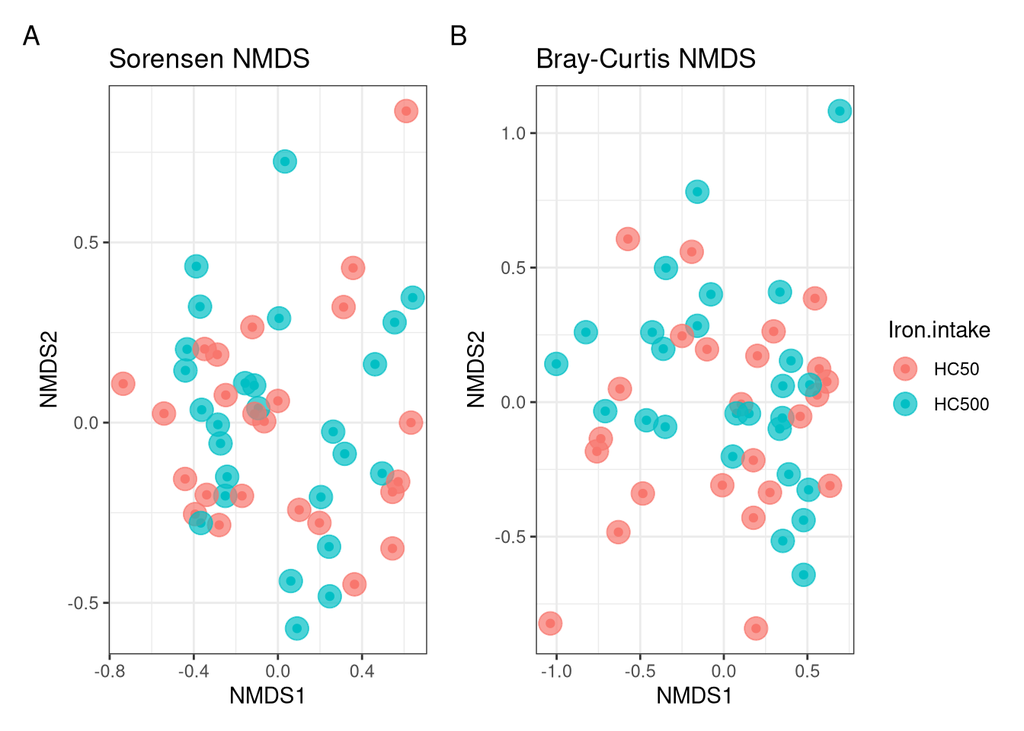

```r
# Plot it: Sorensen NMDS
sorensen_nmds_plot <-
  plot_ordination(
    physeq = scaled_physeq,
    ordination = scaled_sorensen_nmds,
    color = "Iron.intake",
    title = "Sorensen NMDS"
  ) +
  geom_point(size = 5, alpha = 0.7) +
  theme_bw() +
  theme(legend.position = "right")


# Show the plots
sorensen_nmds_plot + bray_nmds_plot +
  plot_layout(guides = "collect") +
  plot_annotation(tag_levels = "A")
```

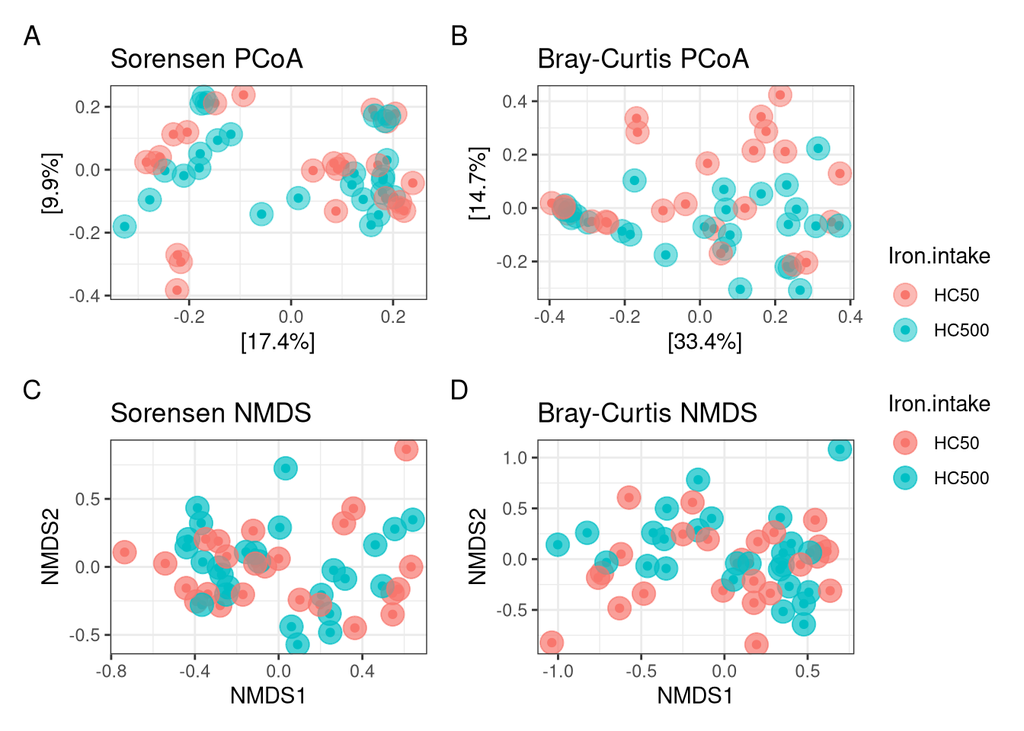

```r
# Show plot
sorensen_pcoa_plot + bray_pcoa_plot +
sorensen_nmds_plot + bray_nmds_plot +
  plot_layout(guides = "collect") +
  plot_annotation(tag_levels = "A")
```

###INTERPRETATION 7: Plot both the PCoA and NMDS together. Which of the two ordination methods best represents your data and why? Consider the strengths and limitations of each method. For example, the variance explained by each PCoA axis versus the stress value of the NMDS could be used to justify your choice. Do both methods support the same biological conclusions?

Among these 4 plots, PCoA best represents this data set because the Bray–Curtis PCoA explains a relatively high proportion of variation in the first two axes (48.1%), making the dominant beta-diversity patterns easier to interpret, whereas NMDS relies on stress values rather than variance explained. I think Bray–Curtis PCoA is preferable as the primary ordination, with NMDS serving as a secondary secreening for hidden patterns.

```r
# Bray-Curtis Betadisper - Station
dispr_bray_station <- betadisper(scaled_bray_dist, metadata_df$Iron.intake)
permutest(dispr_bray_station)
```

```
##
## Permutation test for homogeneity of multivariate dispersions
## Permutation: free
## Number of permutations: 999
##
## Response: Distances
##           Df  Sum Sq  Mean Sq      F N.Perm Pr(>F)
## Groups     1 0.01199 0.011994 0.9202    999  0.359
## Residuals 48 0.62560 0.013033
```

###INTERPRETATION 10: Overall, results seen here suggested that gut microbial community composition did not differ significantly between HC_50 and HC_500 mice, and within group variability was similar. Therefore, a 10-fold difference in dietary non-heme iron did not produce a clear overall shift in beta-diversity, though subtle taxon-level changes may still be present.